# VH Study 3v2: Random Slopes as Structural Predictor and Outcome

Author

Michael Hallquist and Zach Vig

Published

August 26, 2026

# 1 Executive summary

Study 3v2 is the most demanding of the primary v2 studies because estimated random slopes appear on both sides of the structural equation. The predictor process is denoted $y$ in the simulation code and the outcome process is denoted $q$. The amended DGM uses the shared shape-preserving calibration for both processes: posterior reliability changes while the intercept variance, slope variance, and covariance retain a common shape ($\tau_1^2/\tau_0^2=1$).

All 864 planned conditions are complete, with all 11 methods and 1,000 replications per condition. This report reads only Study 3v2 condition files and stops if any legacy or incomplete output is encountered. The original Study 3 Rmd is retained unchanged as the archive of the v1 analysis.

The principal findings are:

1. Stabilized Fuller has complete interval eligibility, small average bias (-0.007), and 95.9% non-null conditional coverage. Its performance is close to nominal when predictor reliability is .80, but conservative when predictor reliability is .25.
2. Low predictor reliability, more than low outcome reliability, defines the difficult regime. At predictor reliability .25, all three feasible latent- uncertainty methods have inflated typical SEs, conservative null tests, and method-specific bias or fit problems. When predictor reliability is .80, stabilized Fuller is close to centered and nominal even if outcome reliability remains .25.
3. Lai 2S-PA conditionally covers well but has positive bias and incomplete interval eligibility. Its non-null eligibility is 79.6%, so its 95.8% conditional coverage corresponds to only 76.0% probability of both producing an eligible interval and covering.
4. MSEM also has serious availability costs in this two-process design: non-null interval eligibility is 62.7%. Its conditional intervals are conservative on average, particularly when the predictor process has reliability .25.
5. Fuller’s low-reliability protection is not exact calibration. Its average null Type I error is 3.0%; at predictor reliability .25 it is near 1%, whereas it is near 5% at predictor reliability .80. This is substantive overcoverage.
6. The one-sided and naive score regressions confirm why a two-sided correction is needed. Some are attenuated; regressions that retain low-reliability BLUP predictors also develop catastrophic coefficient tails. Neither unshrinking the outcome alone nor unshrinking both sides without correcting predictor measurement error is a general solution.

# 2 Scientific motivation

Study 3 represents research questions that relate two person-specific dynamic features. Examples include asking whether an individual’s affective-reactivity slope predicts that same individual’s symptom-reactivity slope, or whether a learning-rate parameter predicts a later change parameter. Both scientific variables are latent random slopes recovered from repeated measurements, so uncertainty enters on both sides of the structural equation.

A compact representation is

$$\begin{aligned}
y_{it} &= \gamma_{0y}+\gamma_{1y}x_{it}+y_{0i}+y_{1i}x_{it}+e_{y,it},\\
q_{is} &= \gamma_{0q}+\gamma_{1q}x_{is}+q_{0i}+q_{1i}x_{is}+e_{q,is},\\
q_{1i} &= \theta_0 y_{0i}+\theta_1 y_{1i}+\zeta_i.
\end{aligned}$$

The focal estimand is the standardized $\theta_1$. This construction makes the predictor/outcome asymmetry explicit: noise in $y_{1i}$ contaminates a predictor moment and can attenuate or destabilize the coefficient, whereas noise in $q_{1i}$ primarily increases outcome-side uncertainty unless its shrinkage is left uncorrected.

# 3 Design and v2-only completion contract

The design crosses four cluster counts (50, 100, 150, and 300), three mean cluster sizes for each process (3, 5, and 10), two posterior-reliability targets for each process (.25 and .80), two intercept–slope correlations (0 and .50), and three standardized structural effects (0, .20, and .50). This yields 864 conditions. The null cells support direct Type I error evaluation; non-null cells evaluate bias, coverage, SE calibration, and power-related operational performance.

The methods have distinct roles:

- **Oracle** uses the simulated true $y$ intercept and slope and true $q$ slope.
- Four **score-regression negative controls** cross BLUP versus unshrunk predictor scores with BLUP versus unshrunk outcome scores. They identify which failures arise from outcome shrinkage, predictor shrinkage, or untreated predictor measurement error.
- **Fuller (stabilized)** corrects the predictor moments and propagates both processes’ Stage-1 uncertainty; its algebra variants audit SE-tail stabilization.
- **Lai 2S-PA** fits a two-process latent-variable path model in OpenMx using the Stage-1 scores and error matrices.
- **MSEM** jointly estimates both growth processes and the structural path in Mplus. It avoids generated scores, but asks each sample to estimate a larger latent covariance system.

| item | value |
| --- | --- |
| Expected conditions | 864 |
| Observed conditions | 864 |
| Methods per condition | 11 |
| Replications per condition | 1000 |
| Study version | v2 |
| Calibration version | shape_preserving_v2 |
| Covariance shape fixed | TRUE |
| Slope/intercept variance ratio | 1 |
| Summary artifacts read | 864 |
| Replication artifacts read | 864 |
| Oldest summary artifact (local time) | 2026-08-19 01:49:12 |
| Newest summary artifact (local time) | 2026-08-25 16:45:01 |
| Newest replication artifact (local time) | 2026-08-25 16:45:01 |

Condition summaries drive the main figures and tables. The exact matching replication artifacts drive the MSEM disposition and sentinel diagnostics; the report stops if either artifact set is incomplete.

The focal structural coefficient is the standardized effect of the true $y$ slope on the true $q$ slope, conditional on the $y$ intercept. Thus, in the labels below, **predictor reliability** is `target_reliability_y` and **outcome reliability** is `target_reliability_q`. Keeping this direction clear is important: the two reliabilities do not play symmetric statistical roles.

# 4 Common terminology and performance metrics

The four v2 reports use the same vocabulary and denominator rules. A **simulation condition** (or *cell*) is one combination of design factors, such as the number of clusters, observations per cluster, reliability, correlation, and true structural effect. Unless a pooled count is explicitly reported, summaries give every condition equal weight. This prevents a method with more eligible fits in easy conditions from implicitly receiving more weight. If an entire condition has no eligible interval, its conditional coverage and SE quantities are undefined and are omitted from the cross-condition average; eligibility and success-and-cover still retain that condition’s failures.

## 4.1 Measurement and model terminology

- The **data-generating model (DGM)** is the population mechanism used to create a simulated data set. An **estimand** is the population quantity the analysis is intended to recover; here it is the standardized structural coefficient, not merely a regression coefficient among estimated scores.
- A **cluster** is the Level-2 unit (for example, a person) observed repeatedly at Level 1. A **random intercept** is that unit’s deviation in level; a **random slope** is its deviation in the within-unit association with the Level-1 predictor. The structural regression asks whether these latent between-unit differences predict, or are predicted by, another variable.
- A **BLUP** (best linear unbiased predictor), also called an empirical Bayes score, is the mixed model’s conditional prediction of a cluster’s random effect. BLUPs deliberately shrink noisy cluster estimates toward the population mean. That improves prediction of an individual random effect but generally makes a subsequent regression on the BLUP target a shrunken quantity rather than the intended latent-effect relation.
- An **unshrunk score** reverses the fitted BLUP shrinkage map to recover a score on the latent random-effect scale. Unshrinking repairs the shrinkage target, but the recovered score remains noisy. If it is used as a predictor, Stage 2 must still account for its measurement-error covariance.
- **Fuller (stabilized)** is the proposed two-stage moment correction. It uses unshrunk scores and their estimated Stage-1 error-covariance matrices, then stabilizes the sampling-variance calculation. The book-equation and alpha-stepdown versions are algebra and tail-sensitivity checks. References to the variance **bread** mean the inverse sensitivity/information component of a sandwich variance estimator, not a second point-estimation correction.
- **Lai 2S-PA** is Lai’s two-stage path-analysis approach: Stage-1 scores and their uncertainty enter a latent-variable path model. **2S-PAA** replaces row-specific uncertainty by an average matrix. **MSEM** is a one-stage multilevel structural equation model. An **oracle** uses the simulated true random effects and supplies a finite-sample benchmark that an applied method cannot attain in real data.
- A **negative control** is a deliberately inadequate estimator whose expected failure has diagnostic value. For example, naive BLUP regression should show shrinkage attenuation. If it did not, the simulation or reporting pipeline would itself require scrutiny.

**Marginal posterior slope reliability** is the primary information target:

$$R = 1 - \frac{E\{V_{i,\mathrm{post}}[\mathrm{slope},\mathrm{slope}]\}}
{G[\mathrm{slope},\mathrm{slope}]}.$$

Here, $G$ is the population random intercept–slope covariance matrix and $V_{i,\mathrm{post}}$ is the remaining posterior uncertainty for cluster $i$ under its observation schedule. Thus, $R=.80$ means that the repeated measurements remove about 80% of the slope’s prior or marginal uncertainty, not that 80% of single observations are signal. **Residualized-slope reliability**, $R_\eta$, applies the same idea to the component of the slope left after its linear association with the random intercept is removed. It can differ from marginal reliability when intercepts and slopes correlate.

An **ICC** is a variance share for an observation under a specified predictor value or contrast. It is not interchangeable with posterior reliability: posterior reliability also uses the number and placement of repeated observations. The v2 **shape-preserving calibration** varies Level-1 residual noise to attain the requested $R$ while holding the slope/intercept variance ratio and intercept–slope correlation fixed. Reliability contrasts therefore do not silently become contrasts in latent covariance geometry.

The **condition number** summarizes how unequal the principal variances of a covariance matrix are: one is perfectly balanced, while a very large value signals near-singularity and numerical sensitivity. A covariance estimate is **positive definite** when it represents strictly positive variation in every linear combination of its latent variables. Zero/negative variances or a nonpositive eigenvalue place a fitted covariance on or beyond an inadmissible boundary.

## 4.2 What each performance quantity answers

[output not shown]

A **Monte Carlo confidence interval** applies the Monte Carlo SE (or a binomial interval for a rate) to a simulation summary. It asks how precisely the simulation has estimated performance. A 95% **Wald confidence interval** in an individual replication is instead the fitted coefficient plus or minus a normal critical value times its model SE; those are the intervals whose coverage is being evaluated.

The standard-error calibration plots require one additional distinction. For each condition $c$, the report computes

$$Q_c =
\frac{\text{mean reported SE among interval-eligible replications}}
{\text{empirical SD of estimates in that same eligible subset}}.$$

The figures then show the **median of $Q_c$ across the nuisance conditions** represented by a point. They do not show a median SE divided by an SD. A ratio near one means that the method’s typical reported uncertainty agrees with its observed repeated-sample variability; values above one indicate typically conservative SE scale, and values below one indicate typically anti-conservative SE scale. The median is used so a few extreme condition-level ratios do not determine the display.

Near-one SE scale is necessary but not sufficient for calibrated intervals. Coverage can still be poor because estimates are biased, standardized errors are skewed or heavy-tailed, SEs covary with estimation error, or only a selected subset of fits is eligible. Accordingly, the reports also inspect the replication-level **standardized error** $(\widehat\beta-\beta)/\widehat{\mathrm{SE}}$. Its SD should be near one when studentization is working; tail summaries reveal failures that a median $Q_c$ can hide.

Fitted posterior reliability and the empirical squared correlation between a true simulated slope and its BLUP answer related but different questions. The first is model-based and computed from fitted covariance/posterior-variance quantities; the second directly measures score recovery in the simulation. They need not be numerically identical in finite samples.

# 5 Reliability manipulation checks

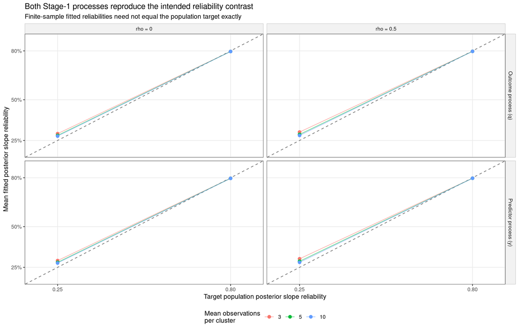

The population calibrator attains the target by construction. The fitted reliabilities summarize the Stage-1 covariance estimates and posterior covariances obtained within the Monte Carlo samples. Their modest deviations from the diagonal are finite-sample estimation effects, not a return to the v1 one-coordinate calibration. Crucially, both processes use the same covariance shape and calibration rule.

# 6 Bias

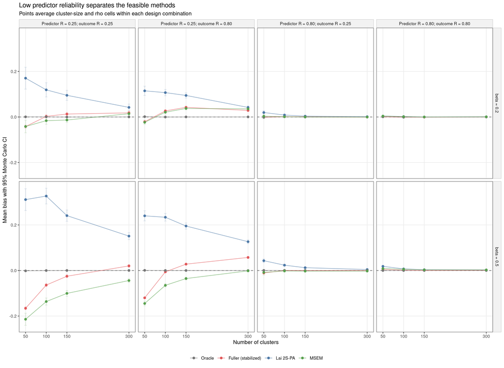

Stabilized Fuller is essentially centered whenever predictor reliability is .80. At low predictor reliability, its bias is modestly negative when both processes have low reliability and close to zero on average when only the predictor is low, although individual cells remain variable. Lai 2S-PA shows substantial positive bias in both low-predictor-reliability panels. MSEM is negatively biased in the low–low panel but much closer to centered when outcome reliability is .80.

The asymmetry is substantively useful. Low outcome reliability alone mainly increases sampling uncertainty. Low predictor reliability contaminates the structural moment matrix and is therefore the condition in which measurement- error correction, numerical stability, and interval construction are most challenging.

## 6.1 One-sided and naive score regressions

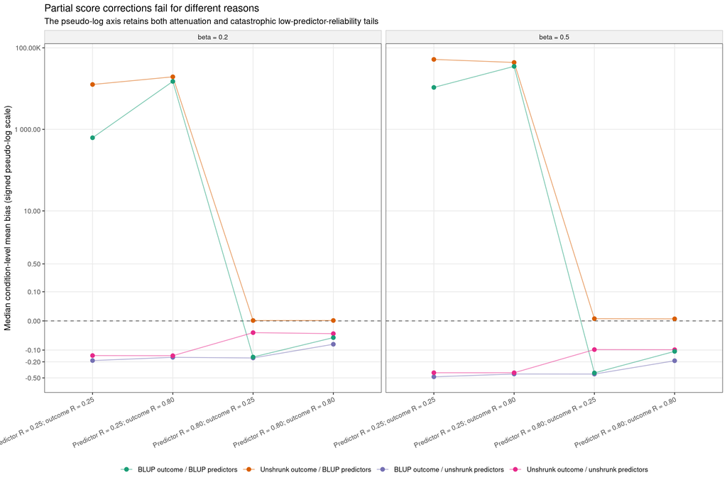

# 7 Coverage and standard-error calibration

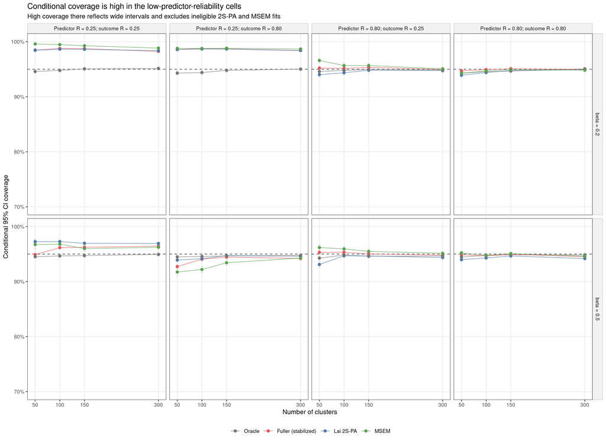

The broad v1 low-reliability undercoverage pattern does not recur. However, high conditional coverage is not automatically evidence of ideal inference. With predictor reliability .25, Fuller’s typical SE is about 45%–61% larger than the empirical SD, depending on outcome reliability. Lai 2S-PA and MSEM are at least as conservative among eligible fits. When predictor reliability is .80, all four methods have typical SE ratios near one and coverage much closer to 95%.

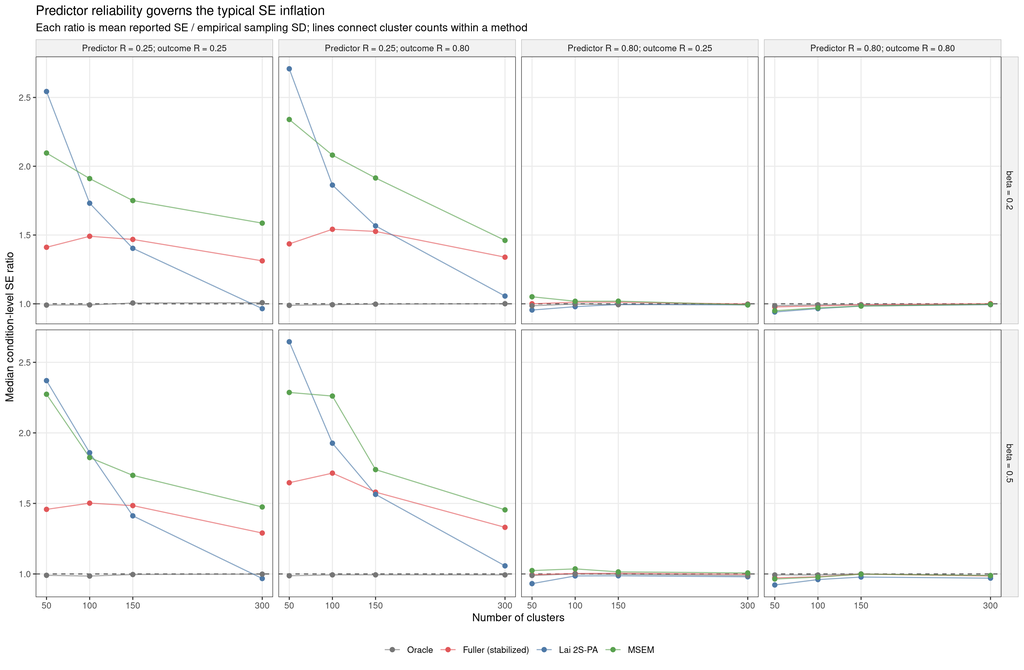

# 8 Conditional versus operational performance

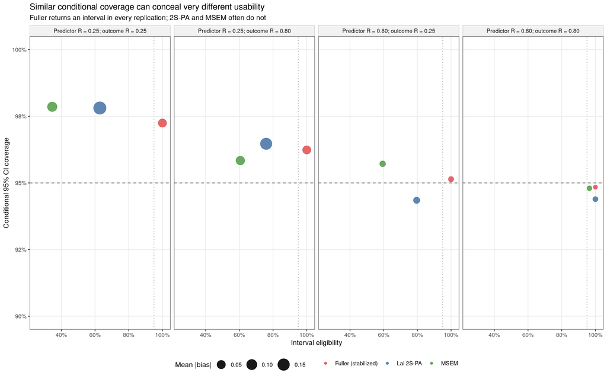

At low reliability for both processes, stabilized Fuller has 97.2% conditional coverage and complete eligibility. Lai 2S-PA has 97.8% coverage among eligible intervals, but only 62.8% eligibility. MSEM eligibility falls to 34.6%. The probability of obtaining an interval that covers is consequently only 61.4% for 2S-PA and 33.8% for MSEM, compared with 97.2% for Fuller.

This operational comparison should not be interpreted as granting failed fits zero coverage in a conventional conditional-coverage estimand. Rather, it answers the practical question a user faces: what proportion of repeated samples yield a usable interval that contains the truth? Reporting both quantities prevents a method from appearing well calibrated merely because difficult replications are excluded.

# 9 Why MSEM loses eligibility and success-and-cover

MSEM’s poor operational performance is primarily a **model-solution problem**, not an interval-construction problem. Under the prespecified eligibility contract, an MSEM point estimate is excluded when Mplus does not return an estimable result, when estimation has a nonzero status, when the focal path is not unique, or when Mplus reports a critical warning such as a non-positive- definite latent covariance matrix. An interval then additionally requires a finite positive SE and ordered confidence limits. In Study 3v2, point and interval eligibility are identical in every MSEM cell (maximum absolute difference = 0.000). Thus, no material attrition occurs because an otherwise admissible point estimate merely lacks a usable SE or confidence limit.

Across all 864,000 MSEM replications, 561,407 (65.0%) produce an eligible interval. The two exact exclusion categories are critical Mplus warnings in 243,013 replications (28.1%) and estimation being unavailable in 59,580 replications (6.9%). The first category often contains a numerical solution and focal coefficient, but the solution is not accepted because the fitted latent covariance structure is inadmissible. Treating those coefficients as successful estimates would make MSEM look more available only by relaxing the definition of a valid fitted model.

[figure not shown]

The narrow orange portions are the replications that yield an eligible interval but miss the true value. In the low-low reliability cells, conditional coverage among eligible fits is very high: it averages 99.6% for $\beta=0$, 99.3% for $\beta=.2$, and 96.4% for $\beta=.5$. The corresponding success-and-cover rates are only 40.7%, 38.2%, and 29.4%, because most samples never reach the conditional coverage calculation. This is the key reason that MSEM can display reassuring conditional coverage and poor success-and-cover at the same time.

## 9.1 What is going wrong in the fitted MSEM?

The MSEM jointly estimates two intercept–slope growth processes and regresses the outcome slope (`S2`) on the predictor intercept and slope (`I1` and `S1`). This asks each sample to support two latent covariance blocks plus the structural relation. When the slopes are weakly measured, the level-2 sample contains too little information to keep all of those variance and covariance estimates well inside the admissible parameter space.

A replication-level audit of condition 3893 provides a concrete example. This is a deliberately difficult null condition with 50 clusters, three observations per process, zero intercept–slope correlation, and posterior reliability .25 for both slopes. Of its 1,000 MSEM fits, only 245 produce eligible intervals; 594 end with a critical warning despite a zero estimation status, and 161 do not return an estimate. Every critical warning states that the latent covariance matrix (`PSI`) is not positive definite. The variable named in the warning is:

| Latent variable named by Mplus | Replications | Percent of 1,000 samples |
| --- | --- | --- |
| Outcome slope (S2) | 234 | 23.4% |
| Outcome intercept (I2) | 196 | 19.6% |
| Predictor slope (S1) | 124 | 12.4% |
| Predictor intercept (I1) | 40 | 4.0% |

The outcome block is especially prominent: `S2` or `I2` is named in 430 of the 594 critical warnings. The fitted covariance diagnostics tell the same story. Among the eligible fits, neither latent covariance block is flagged as being on a boundary and the average minimum eigenvalues are positive. Among the ineligible fits for which diagnostics can be parsed, nonpositive variance estimates and an inadmissible outcome covariance block are common:

| eligibility | Replications | Mean minimum variance | Mean nonpositive-variance count | Predictor covariance boundary | Outcome covariance boundary | Predictor minimum eigenvalue | Outcome minimum eigenvalue |
| --- | --- | --- | --- | --- | --- | --- | --- |
| Eligible | 245 | 0.547 | 0.000 | 0.000 | 0.000 | 0.686 | 0.512 |
| Ineligible | 755 | -0.651 | 0.958 | 0.276 | 0.774 | 0.240 | -0.776 |

This sentinel is not an isolated anomaly. Across the 864 MSEM cells, the cell-level correlation between interval ineligibility and the rate of a critical Mplus warning is 0.982; the correlation between ineligibility and an outcome latent-covariance boundary is 0.933. Boundary diagnostics are only available when enough Mplus output can be parsed, so they do not themselves count the fully unavailable fits. The exact exclusion counts above remain the primary attrition analysis.

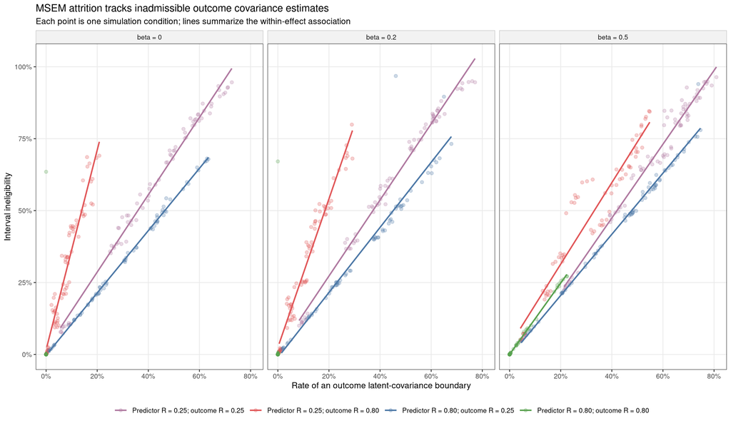

## 9.2 Which design features amplify the problem?

The number of level-2 units is the clearest protection against MSEM ineligibility. Averaged over the other factors, eligibility in the low-low reliability regime rises from 11.9% with 50 clusters to 64.5% with 300 clusters. In the high-high regime it rises from 91.4% to 99.9%.

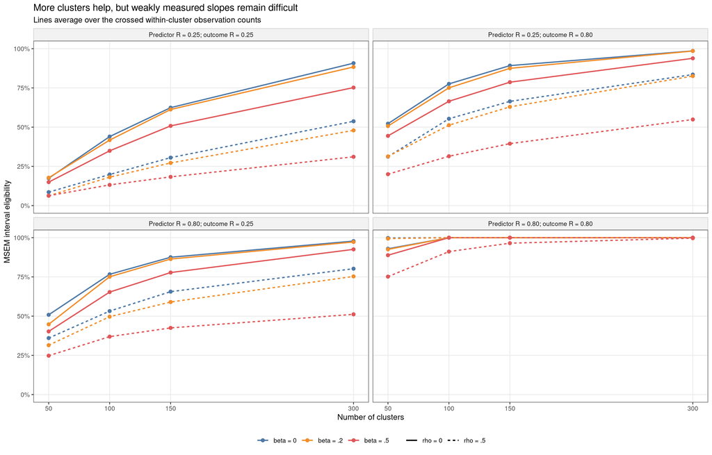

Three secondary patterns are informative. First, low outcome reliability is directly associated with instability in the `I2`–`S2` covariance block. Second, low predictor reliability also matters because `S1` is an uncertain latent predictor in the structural regression. Third, the $ρ=.5$ covariance shape and the larger structural effect both reduce eligibility, especially at low reliability. In this parameterization, `S2` is endogenous, so the variance reported for it by Mplus is its residual variance conditional on `I1` and `S1`, not its total marginal variance. As the structural path strengthens, that residual component can lie closer to a boundary in finite samples. This helps explain why eligibility at low-low reliability falls from 40.9% under the null to 30.6% at the largest effect.

The within-cluster observation count has much less independent leverage here than the number of clusters. That result is consistent with the v2 DGM: the measurement-error scale is recalibrated as the observation count changes so that posterior slope reliability remains at its target. Consequently, adding observations while holding the reliability target fixed is not the same as giving MSEM a better-measured slope.

In substantive terms, MSEM’s low success-and-cover is therefore not evidence that its eligible intervals systematically miss the truth. It is evidence that, under weak level-2 information, a relatively elaborate joint latent model often cannot produce an admissible covariance solution. Conditional coverage describes the selected subset that survives this process; success-and-cover records the operational consequence for all samples. Both are needed, and neither should be substituted for the other.

# 10 Type I error

At the null, CI noncoverage and two-sided rejection are the same event among eligible intervals. Type I error is therefore the clearest interpretation of null-condition coverage.

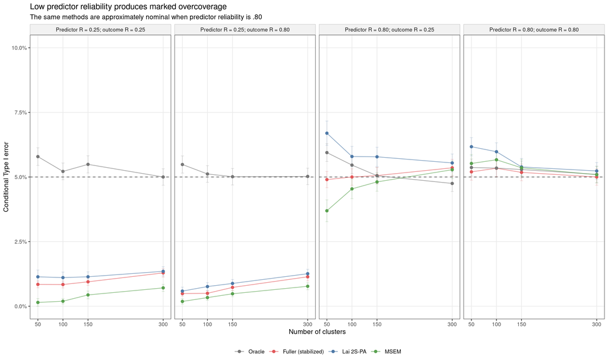

This plot resolves an ambiguity that coverage alone cannot. The very high low-predictor-reliability coverage is inferential conservatism, not merely better centering. Fuller’s null rejection rate is approximately 1% when both reliabilities are .25 and below 1% when predictor reliability is .25 and outcome reliability is .80. It returns to approximately 5% in both panels with predictor reliability .80. Lai 2S-PA and MSEM show the same broad transition, though their conditional rates apply only to eligible fits.

# 11 Direct comparison: stabilized Fuller, Lai 2S-PA, and MSEM

The three methods address the same two-sided uncertainty problem differently. Fuller applies an explicit moment correction using the replication-specific Stage-1 error-covariance matrices; 2S-PA represents the Stage-1 scores and uncertainties in an OpenMx latent-variable model; MSEM estimates both growth processes and the structural relation jointly in Mplus. The matched-cell comparisons below use the same simulated samples and do not rank methods from coverage alone.

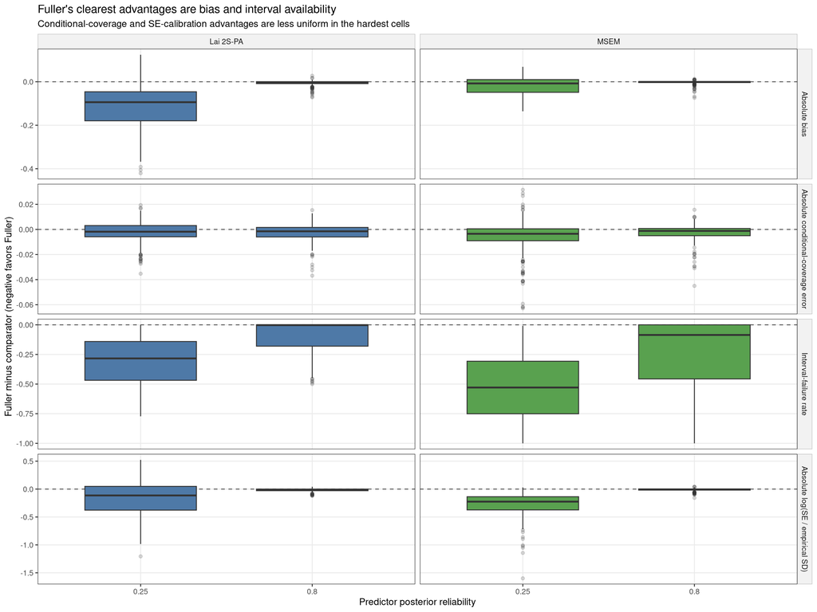

**Why Fuller remains attractive.** It returns finite intervals in all replications, has much smaller bias than 2S-PA when predictor reliability is low, and avoids MSEM’s severe low-reliability fit attrition. When predictor reliability is .80, its point and interval performance are close to oracle performance even if the outcome process is measured poorly.

**Where 2S-PA is competitive.** Among eligible solutions, 2S-PA often has coverage as close to or closer to 95% than Fuller. At high predictor reliability its bias is small. Its liabilities are positive bias and substantial selection of eligible fits when predictor reliability is .25. Conditional coverage therefore answers a narrower question for 2S-PA than for Fuller.

**Where MSEM is competitive.** In the high–high reliability condition MSEM is very similar to Fuller and 2S-PA. Joint estimation is also theoretically appealing because it avoids treating estimated scores as observed. In this simulation, however, MSEM has the lowest eligibility in the difficult cells, and the eligible low-reliability fits remain conservative. Its average null Type I error is not closer to 5% than Fuller’s in Study 3v2, unlike the clearer MSEM advantage observed in some one-process settings.

| Method | Predictor R | Outcome R | Mean bias | Mean \|bias\| | Conditional coverage | Interval eligible | Success-and-cover | Median condition-level SE ratio | Null Type I error | Null interval eligible |
| --- | --- | --- | --- | --- | --- | --- | --- | --- | --- | --- |
| Fuller (stabilized) | 0.25 | 0.25 | -0.030 | 0.048 | 97.2% | 100.0% | 97.2% | 1.450 | 1.0% | 100.0% |
| Lai 2S-PA | 0.25 | 0.25 | 0.182 | 0.184 | 97.8% | 62.8% | 61.4% | 1.597 | 1.2% | 62.9% |
| MSEM | 0.25 | 0.25 | -0.069 | 0.078 | 97.9% | 34.6% | 33.8% | 1.830 | 0.4% | 40.9% |
| Fuller (stabilized) | 0.25 | 0.80 | 0.005 | 0.047 | 96.2% | 100.0% | 96.2% | 1.608 | 0.7% | 100.0% |
| Lai 2S-PA | 0.25 | 0.80 | 0.144 | 0.144 | 96.5% | 75.9% | 73.2% | 1.772 | 0.9% | 75.7% |
| MSEM | 0.25 | 0.80 | -0.022 | 0.058 | 95.8% | 60.6% | 58.3% | 2.087 | 0.4% | 69.3% |
| Fuller (stabilized) | 0.80 | 0.25 | -0.001 | 0.007 | 95.1% | 100.0% | 95.1% | 1.002 | 5.1% | 100.0% |
| Lai 2S-PA | 0.80 | 0.25 | 0.015 | 0.016 | 94.3% | 79.5% | 75.1% | 0.979 | 6.0% | 79.4% |
| MSEM | 0.80 | 0.25 | -0.001 | 0.011 | 95.7% | 59.4% | 56.7% | 1.021 | 4.6% | 68.5% |
| Fuller (stabilized) | 0.80 | 0.80 | 0.001 | 0.003 | 94.8% | 100.0% | 94.8% | 0.987 | 5.2% | 100.0% |
| Lai 2S-PA | 0.80 | 0.80 | 0.005 | 0.006 | 94.4% | 100.0% | 94.4% | 0.965 | 5.7% | 100.0% |
| MSEM | 0.80 | 0.80 | 0.003 | 0.005 | 94.8% | 96.5% | 91.4% | 0.978 | 5.4% | 99.1% |

# 12 Fuller variants and SE tails

The corrected Fuller implementation retains several algebra/regularization variants as diagnostics. They share the corrected zero predictor–outcome measurement-error covariance for this DGM. The variants differ in the preliminary moment and variance-bread choices used to regularize the sampling- variance tail.

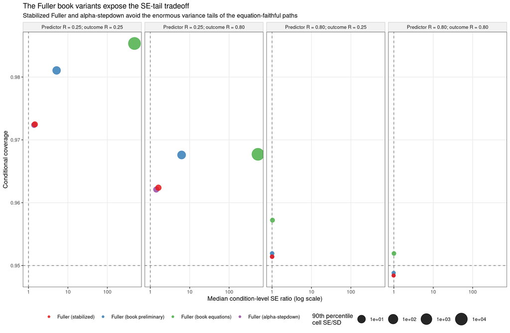

The variants have similar point bias because they use closely related coefficient corrections. Their interval behavior differs sharply. The book- equation path has a much larger typical SE ratio and an extreme upper tail; the book-preliminary path is less extreme but remains heavy-tailed. Stabilized Fuller and alpha-stepdown keep the typical SE scale near one and control the tail far more effectively. These results support the stabilized path as the proposed estimator while retaining the other variants as transparency and sensitivity checks.

# 13 Conclusions

Study 3v2 changes the interpretation of the earlier two-process results in several important ways.

- The shape-preserving reliability calibration removes the apparent general low-reliability coverage failure seen under the v1 one-coordinate DGM. The remaining difficulty is structured rather than global: it is concentrated in low **predictor** reliability.
- Stabilized Fuller offers the strongest overall compromise for the proposed use case. It has complete availability, low average bias, and approximately nominal performance when predictor reliability is adequate. It also avoids the catastrophic coefficient tails of naive or partially corrected score regressions.
- Fuller is not fully calibrated in the hardest cells. With predictor reliability .25, its SEs are too large relative to empirical sampling variability and its null rejection rate is far below 5%. The paper should describe this as conservative inference, not as unqualified 95% coverage success.
- Lai 2S-PA and MSEM do not provide a simple remedy. Both can have attractive conditional coverage, but both lose many eligible intervals in the same cells where Fuller’s intervals become conservative. 2S-PA also has marked positive bias at low predictor reliability. MSEM’s attrition occurs before interval construction: most excluded fits either have a non-positive- definite latent covariance matrix or do not return an estimate. It is not principally a case of valid point estimates acquiring unusable SEs.
- Outcome-side reliability still matters, but primarily by changing uncertainty and fit difficulty. A poorly measured outcome does not cause the same attenuation mechanism as a poorly measured predictor. This asymmetry should be made explicit when explaining Study 3 to a psychological methods audience.
- The null cells are indispensable. They show that high coverage for Fuller, 2S-PA, and MSEM at low predictor reliability corresponds to reduced Type I error, whereas the same methods are near nominal when predictor reliability is .80. Coverage, Type I error, bias, fit eligibility, and SE calibration should therefore be reported together.

For the manuscript, the balanced conclusion is that stabilized Fuller is an attractive and unusually available estimator for two-sided random-slope relations, especially once predictor reliability is moderate or high. Its practical advantage in the hardest cells is that it continues to return usable results with much less bias than 2S-PA, not that its intervals are exactly nominal there. A reasonable applied recommendation is to report the Stage-1 posterior reliability of the predictor slopes, treat very low values as a warning for conservative Fuller intervals and unstable latent-variable fits, and accompany the structural result with the reliability and fit diagnostics used in this report.

# 14 Appendix

## 14.1 Overall method summaries

Cell counts require the condition-level 95% Monte Carlo interval to lie wholly below or above .95.

| Method | Cells | Interval eligible | Mean bias | Mean \|bias\| | Conditional coverage | Success-and-cover | Median condition-level SE ratio | MC interval below .95 | MC interval above .95 |
| --- | --- | --- | --- | --- | --- | --- | --- | --- | --- |
| Fuller (stabilized) | 576 | 100.0% | -0.007 | 0.026 | 95.9% | 95.9% | 1.033 | 49 | 198 |
| Lai 2S-PA | 576 | 79.6% | 0.086 | 0.087 | 95.8% | 76.0% | 1.006 | 69 | 204 |
| Oracle | 576 | 100.0% | 0.000 | 0.002 | 94.7% | 94.7% | 0.994 | 39 | 3 |
| MSEM | 576 | 62.7% | -0.022 | 0.038 | 96.1% | 60.0% | 1.105 | 43 | 182 |

## 14.2 Null summaries

| Method | Cells | Interval eligible | Mean bias | Conditional Type I error | Operational Type I error | Conditional coverage |
| --- | --- | --- | --- | --- | --- | --- |
| Fuller (stabilized) | 288 | 100.0% | 0.004 | 3.0% | 3.0% | 97.0% |
| Lai 2S-PA | 288 | 79.5% | -0.008 | 3.4% | 2.9% | 96.6% |
| Oracle | 288 | 100.0% | 0.000 | 5.3% | 5.3% | 94.7% |
| MSEM | 288 | 69.4% | 0.010 | 2.7% | 2.3% | 97.3% |

## 14.3 Negative-control tail summary

| Method | Predictor R | Median cell bias | Mean \|cell bias\| | Maximum \|cell bias\| | Cells with \|bias\| > .5 | Interval eligible |
| --- | --- | --- | --- | --- | --- | --- |
| BLUP outcome / BLUP predictors | 0.25 | 11302.200 | 6.16e+04 | 1.9e+06 | 96.5% | 82.5% |
| BLUP outcome / BLUP predictors | 0.80 | -0.135 | 0.172 | 0.402 | 0.0% | 100.0% |
| Unshrunk outcome / BLUP predictors | 0.25 | 31786.735 | 1.24e+05 | 2.18e+06 | 96.5% | 82.5% |
| Unshrunk outcome / BLUP predictors | 0.80 | 0.003 | 0.00629 | 0.0404 | 0.0% | 100.0% |
| BLUP outcome / unshrunk predictors | 0.25 | -0.293 | 0.302 | 0.475 | 0.0% | 100.0% |
| BLUP outcome / unshrunk predictors | 0.80 | -0.168 | 0.205 | 0.422 | 0.0% | 100.0% |
| Unshrunk outcome / unshrunk predictors | 0.25 | -0.259 | 0.256 | 0.381 | 0.0% | 100.0% |
| Unshrunk outcome / unshrunk predictors | 0.80 | -0.066 | 0.0626 | 0.13 | 0.0% | 100.0% |

## 14.4 Production artifact provenance

The table describes the recorded environment that generated the condition artifacts, not merely the environment used to render this report.

Distinct production environments recorded for condition IDs 3893–4756 (173 metadata files).

| Pipeline | Git commit | Dirty worktree | Requested replications | R | Mplus | OpenMx | MplusAutomation | lme4 |
| --- | --- | --- | --- | --- | --- | --- | --- | --- |
| openmx_one_row_stage1_covariance_v6_20260817 | 66b464920b3c823bff667ac069698c51a8c87f42 | TRUE | 1000 | R version 4.5.1 (2025-06-13) | Mplus VERSION 8.9 (Linux) | 2.22.11 | 1.4 | 2.0.1 |
| openmx_one_row_stage1_covariance_v6_20260817 | a33519fb5f8b45ab570f4eeae7e3a0b742c5b988 | TRUE | 1000 | R version 4.5.1 (2025-06-13) | Mplus VERSION 8.9 (Linux) | 2.22.11 | 1.4 | 2.0.1 |
| openmx_one_row_stage1_covariance_v6_20260817 | 58ef1d4d5d9218fac951ec669a8926f222d0af74 | TRUE | 1000 | R version 4.5.1 (2025-06-13) | Mplus VERSION 8.9 (Linux) | 2.22.11 | 1.4 | 2.0.1 |

**Reproducibility note.** The production metadata record a dirty worktree. The commit hashes are therefore base references, not complete snapshots of the source that generated every artifact. The artifact-level v2, method, replication, and design contracts above still protect this report from legacy or structurally incompatible inputs, but a publication freeze should regenerate the final archive from a clean, tagged commit.